# ASM - Project TS

Gabriel Zarate & Antonio Pariente

2024-01-11

# 1. Identification

Exploratory data analysis and transformation into stationarity

## Import the data

```r
serie=window(ts(read.table("metro.dat"),start=1996,freq=12))
print(round(serie,0))
```

```
##        Jan   Feb   Mar   Apr   May   Jun   Jul   Aug   Sep   Oct   Nov   Dec
## 1996 23827 24093 24648 22899 23961 21645 21086 11758 21363 26739 23783 23214
## 1997 21161 20471 19418 21641 20340 19772 19916 10800 20118 25118 22231 22516
## 1998 22531 23231 26597 23416 24737 23038 23088 14110 23545 25322 24501 24221
## 1999 22934 23628 26147 27000 26320 24085 22062 13907 23989 26028 26444 24177
## 2000 23810 24979 27925 23136 26895 24692 23228 14911 23432 26894 27850 25057
## 2001 26381 25143 28007 24085 28238 25937 25104 16007 23803 29607 27882 25717
## 2002 24803 26296 27351 28736 30941 25702 26637 16707 25046 31036 28534 27093
## 2003 28067 27532 30251 27649 30054 26781 27971 17306 26411 32117 29071 28698
## 2004 28138 28589 32209 28209 30306 29140 27924 19181 28701 30289 30738 29322
## 2005 28429 28957 30064 31912 31862 29398 27916 18251 28519 30439 30959 28560
## 2006 29690 29361 33335 28654 33133 30182 28311 19789 28384 32067 31764 28706
## 2007 30943 29983 34022 30137 33974 31107 29660 21330 28515 34014 32821 29851
## 2008 32314 32116 32234 34893 32990 31201 31907 21203 29808 34876 31932 32314
## 2009 30558 30124 33288 30738 32391 30471 31257 21358 28259 31874 30907 30321
## 2010 29491 30064 34346 32765 34145 32448 32670 23818 31367 34124 33760 32084
## 2011 31762 31584 35301 32803 36349 32599 32224 25185 32611 34226 33156 31185
## 2012 31608 31964 34344 31333 34344 32671 31781 23622 29120 33501 30338 28866
## 2013 30537 29254 31162 32922 33889 30833 31747 23610 29915 34512 31452 30102
## 2014 30503 29736 33131 31611 34084 30812 32436 23806 30966 35455 31630 31548
## 2015 30788 30357 34038 32957 34624 32354 33061 24677 31836 35462 33177 31662
## 2016 30490 30150 32145 34458 34133 30678 31839 25064 32512 34749 33626 31642
## 2017 31915 32107 36921 33154 35863 33215 32038 24729 31780 33937 33943 30793
## 2018 32942 32739 35220 35646 36771 34980 34365 26035 32211 37935 35797 32868
## 2019 35235 33538 37374 34779 37242 33894 32808 24074 32930 38912 36547 34612
```

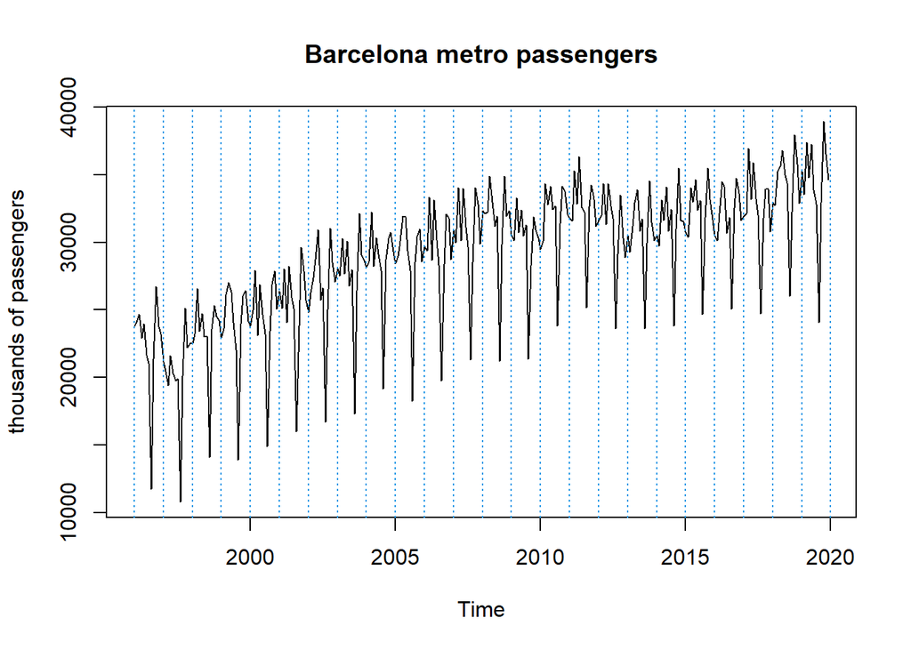

```r
plot(serie,main="Barcelona metro passengers",ylab="thousands of passengers")
abline(v=1996:2020,lty=3,col=4)
```

## Transformation into stationarity

### Check if variance is constant

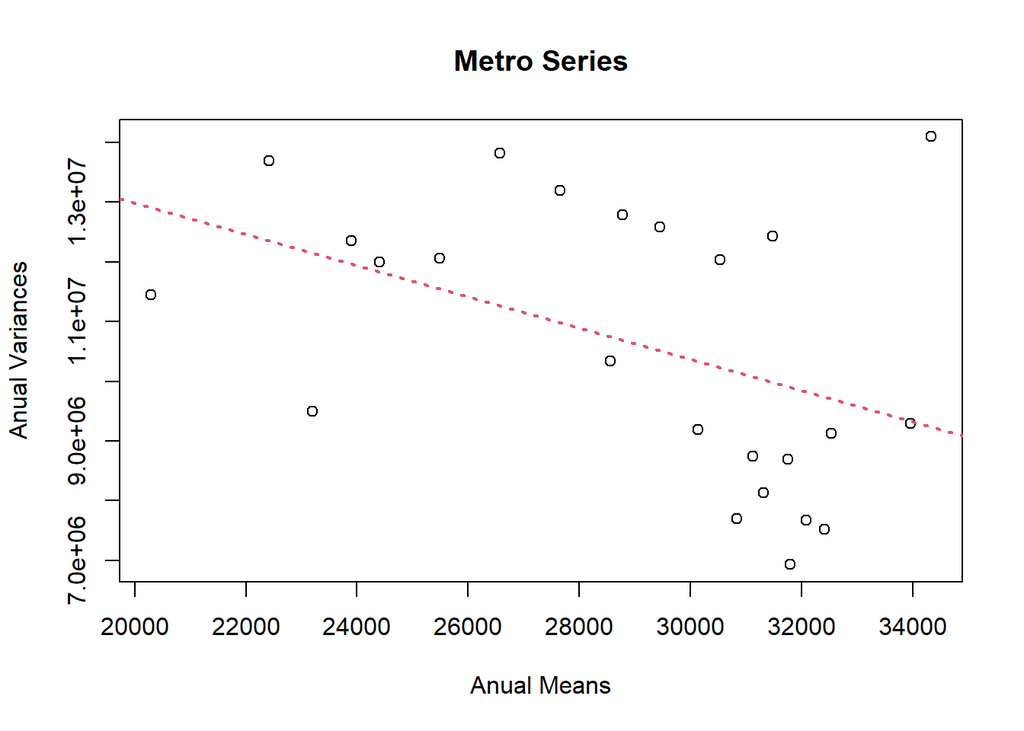

```r
m=apply(matrix(serie,nr=12),2,mean)
v=apply(matrix(serie,nr=12),2,var)
plot(m,v,xlab="Anual Means",ylab="Anual Variances",main="Metro Series")
abline(lm(v~m),col=2,lty=3,lwd=2)
```

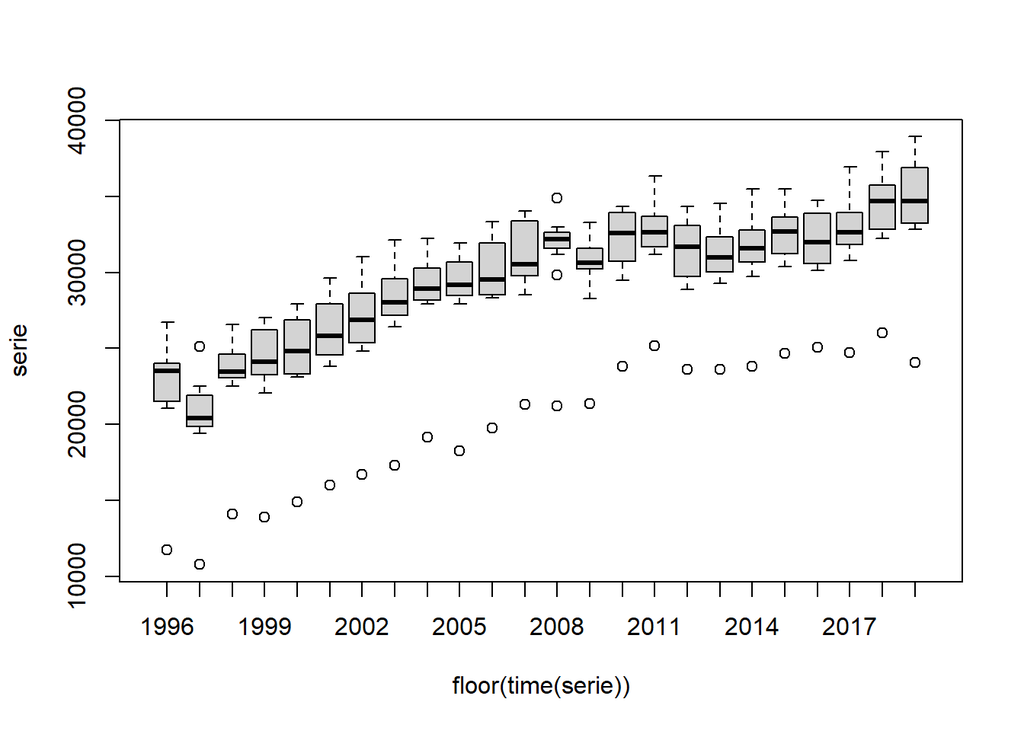

```r
boxplot(serie~floor(time(serie)))
```

The variance seems to be almost constant, but there are some cases that it changes a lot, so we apply the Box-Cox transformation to try to stabilize it more, by applying natural log

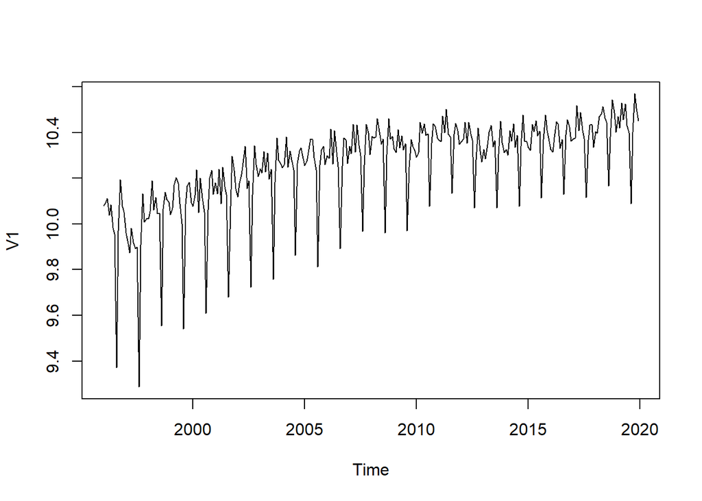

```r
lnserie=log(serie)
plot(lnserie)
```

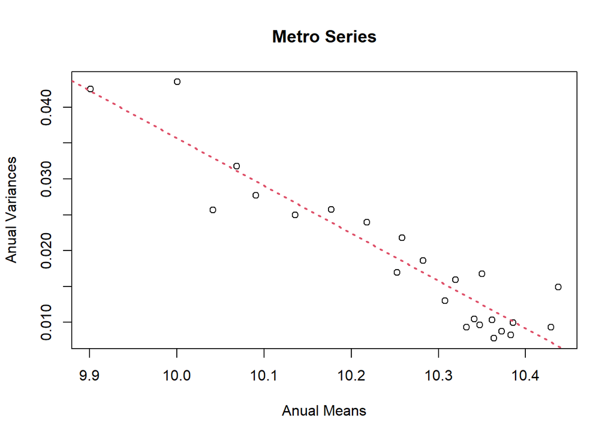

```r
m=apply(matrix(lnserie,nr=12),2,mean)
v=apply(matrix(lnserie,nr=12),2,var)
plot(m,v,xlab="Anual Means",ylab="Anual Variances",main="Metro Series")
abline(lm(v~m),col=2,lty=3,lwd=2)
```

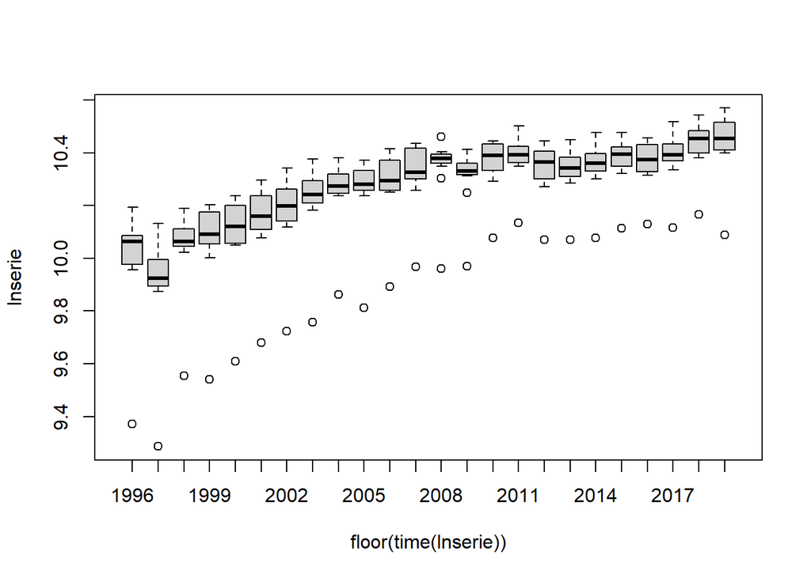

```r
boxplot(lnserie~floor(time(lnserie)))
```

### Check if seasonality is observed/present

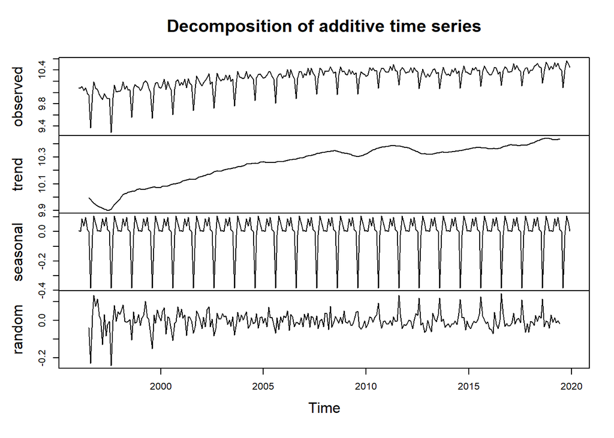

```r
plot(decompose(lnserie))
```

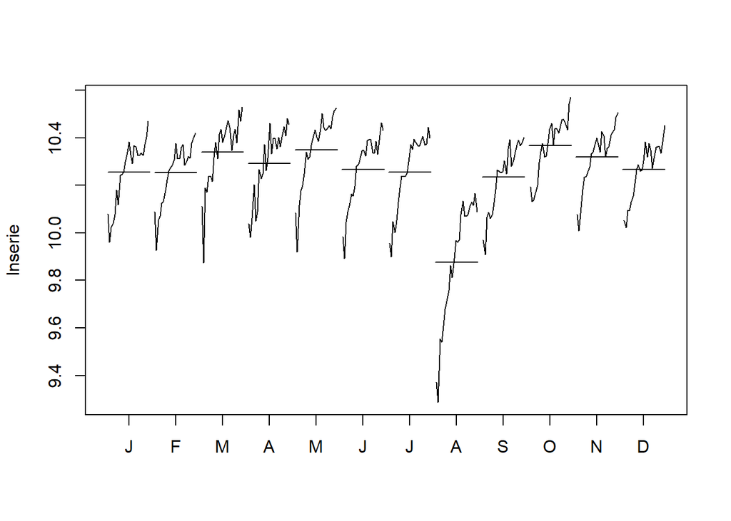

```r
monthplot(lnserie)
```

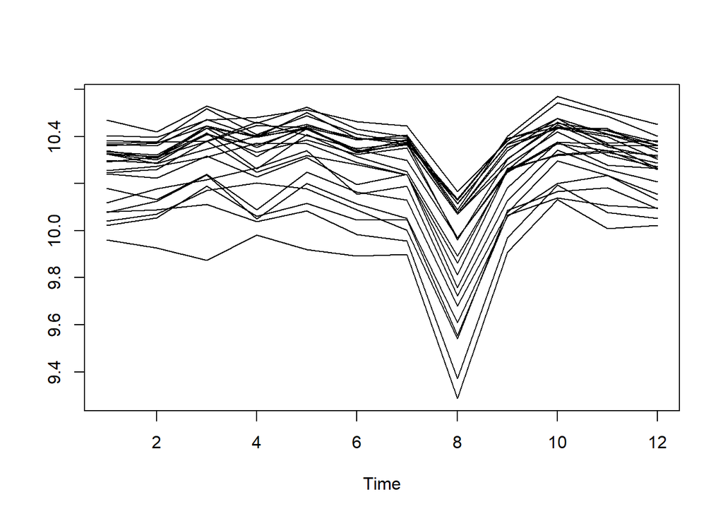

```r
ts.plot(matrix(lnserie,nrow=12))
```

It seems to be a seasonal pattern, that shows that during August the number of passengers significantly reduces, which makes sense because of the time of the season. This because during summer people turns to travel more so there is less people in the city.

So we eliminate the seasonality applying a seasonal difference $(1-B^{12})\log(X_t)$

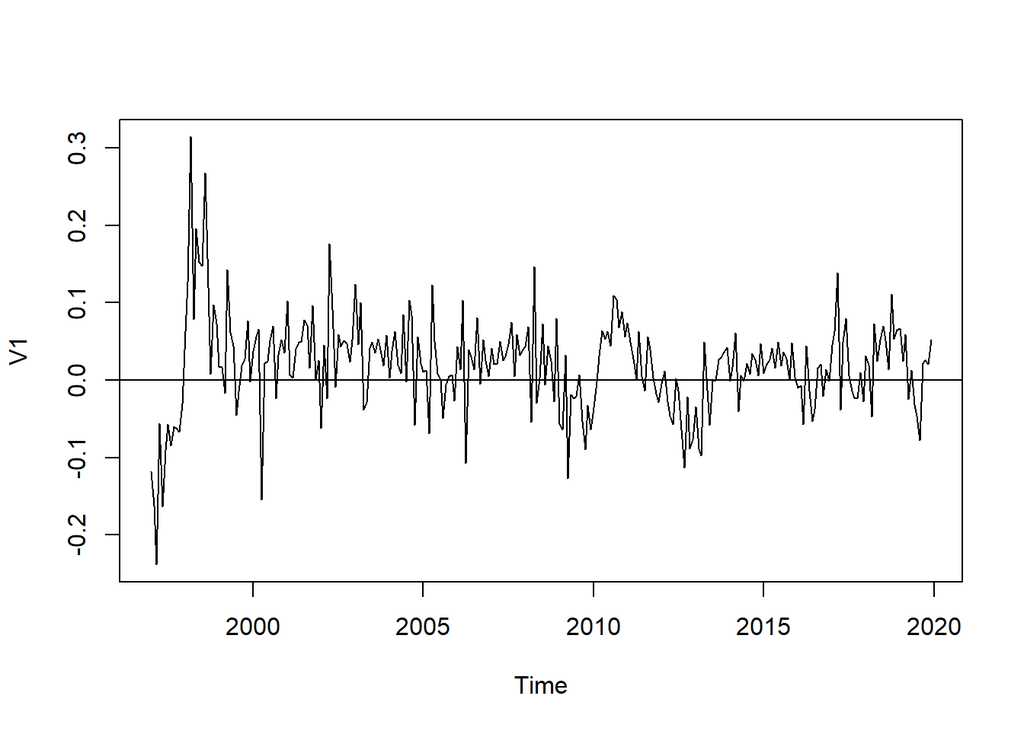

```r
d12lnserie=diff(lnserie,12)
plot(d12lnserie)
abline(h=0)
```

### Check if the mean is constant

Checking the plot done after the seasonal difference, it seems that the mean is not constant, so it is needed to apply a regular difference of order d=1 (1-B)

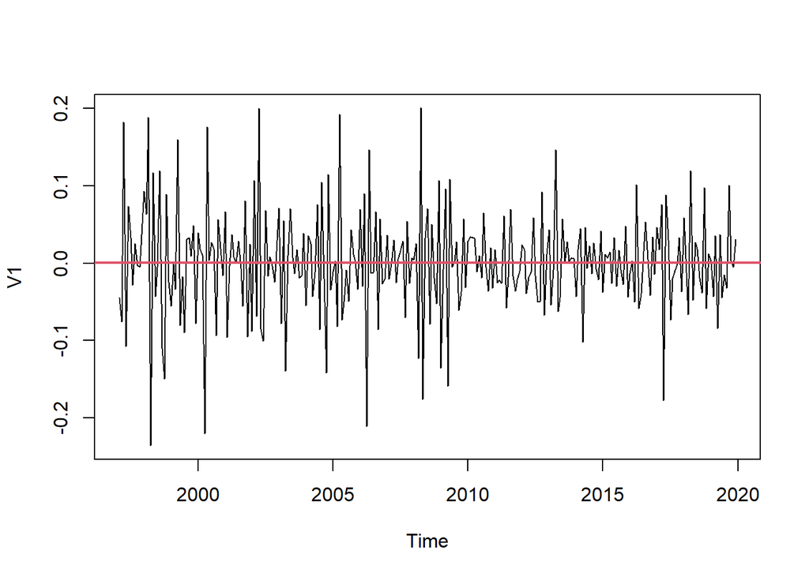

```r
d1d12lnserie=diff(d12lnserie,1)
plot(d1d12lnserie)
abline(h=0)
abline(h=mean(d1d12lnserie),col=2,lwd=2)
```

After that, the mean seems to be constant and around 0, but despite that is decided to try another regular difference and then by checking if the variance increases we will verify if it is needed or not.

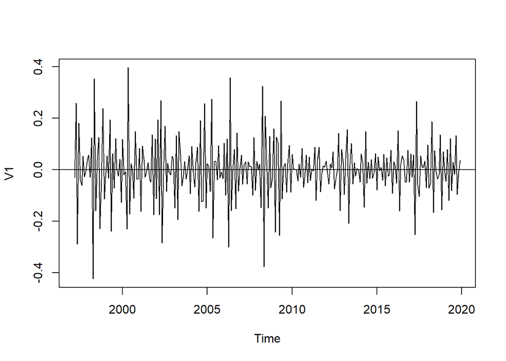

```r
d1d1d12lnserie=diff(d1d12lnserie,1)
plot(d1d1d12lnserie)
abline(h=0)
```

```r
var(lnserie)
```

```
##            V1
## V1 0.03769898
```

```r
var(d12lnserie)
```

```
##             V1
## V1 0.003937954
```

```r
var(d1d12lnserie)
```

```
##             V1
## V1 0.004528142
```

```r
var(d1d1d12lnserie)
```

```
##            V1
## V1 0.01390884
```

The second regular difference is not needed because it is seen that the variance is artificially increased. So finally, stationarity is achieved by double differentiating the log-transformed series (one regular and one seasonal difference).

Thus, $W_t=(1-B)(1-B^{12})\log X_t$ with seemingly zero mean.

It can be concluded that the double differenced (d=1 and D=1) metro_bcn series (d1d12lnserie) is considered to be stationary: it has constant mean (seemingly=0), constant variance, and covariance structure only depending on the lags.

## Model identification

Since stationarity of the series d1d12lnserie was confirmed, we use the patterns observed on the P(ACF) to choose the posible ARIMA models.

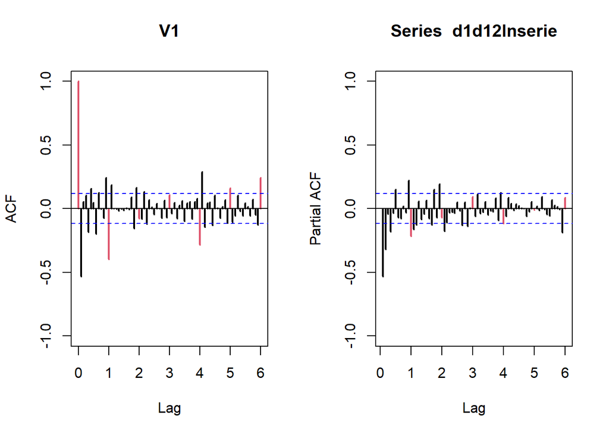

```r
par(mfrow=c(1,2))
acf(d1d12lnserie,ylim=c(-1,1),col=c(2,rep(1,11)),lwd=2,lag.max=72)
pacf(d1d12lnserie,ylim=c(-1,1),col=c(rep(1,11),2),lwd=2,lag.max=72)
```

```r
par(mfrow=c(1,1))
```

Based on the patterns observed in the P(ACF), the identified feasible models for Wt are:

- AR(2) and SAR(1)
- MA(1) and SAR(1)

# 2. Estimation

## Model fitting

### AR(2) and SAR(1)

First, fit the identified $ARIMA(2,0,0)(1,0,0)_{12}$ process to the stationary/transformed series Wt=d1d12lnserie

#### Check/verify if the mean/intercept is truly null (non-statistically significant intercept)

```r
(mod=arima(d1d12lnserie,order=c(2,0,0),seasonal=list(order=c(1,0,0),period=12)))
```

```
##
## Call:
## arima(x = d1d12lnserie, order = c(2, 0, 0), seasonal = list(order = c(1, 0,
##     0), period = 12))
##
## Coefficients:
##           ar1      ar2     sar1  intercept
##       -0.7028  -0.3331  -0.4266      4e-04
## s.e.   0.0568   0.0567   0.0572      1e-03
##
## sigma^2 estimated as 0.002395:  log likelihood = 438.04,  aic = -866.08
```

```r
abs(mod$coef/sqrt(diag(mod$var.coef)))
```

```
##        ar1        ar2       sar1  intercept
## 12.3819915  5.8709289  7.4515931  0.4216957
```

Clearly, only the intercept (mean) is non significant.

Thus, fit the non-stationary $ARIMA(2,1,0)(1,1,0)_{12}$ process to original log-transformed series: Wt=lnserie

```r
(mod1=arima(lnserie,order=c(2,1,0),seasonal=list(order=c(1,1,0),period=12)))
```

```
##
## Call:
## arima(x = lnserie, order = c(2, 1, 0), seasonal = list(order = c(1, 1, 0), period = 12))
##
## Coefficients:
##           ar1      ar2     sar1
##       -0.7024  -0.3327  -0.4268
## s.e.   0.0568   0.0568   0.0573
##
## sigma^2 estimated as 0.002396:  log likelihood = 437.95,  aic = -867.91
```

```r
abs(mod1$coef/sqrt(diag(mod1$var.coef)))
```

```
##       ar1       ar2      sar1
## 12.372541  5.862357  7.453223
```

We can see that:

- All coeffs are non-zero (found statistically significant since |T-ratios| > 2).
- AIC decreased when the intercept was dropped, so it is a good decision to drop the intercept

### MA(1) and SAR(1)

First, fit the identified $ARIMA(0,0,1)(1,0,0)_{12}$ process to the stationary/transformed series Wt=d1d12lnserie

#### Check/verify if the mean/intercept is truly null (non-statistically significant intercept)

```r
(mod=arima(d1d12lnserie,order=c(0,0,1),seasonal=list(order=c(1,0,0),period=12)))
```

```
##
## Call:
## arima(x = d1d12lnserie, order = c(0, 0, 1), seasonal = list(order = c(1, 0,
##     0), period = 12))
##
## Coefficients:
##           ma1     sar1  intercept
##       -0.6631  -0.4289      3e-04
## s.e.   0.0434   0.0581      7e-04
##
## sigma^2 estimated as 0.00243:  log likelihood = 436.01,  aic = -864.02
```

```r
abs(mod$coef/sqrt(diag(mod$var.coef)))
```

```
##        ma1       sar1  intercept
## 15.2624959  7.3823982  0.4611802
```

Clearly, only the intercept (mean) is non significant.

Thus, fit the non-stationary $ARIMA(0,1,1)(1,1,0)_{12}$ process to original log-transformed series: lnserie

```r
(mod2=arima(lnserie,order=c(0,1,1),seasonal=list(order=c(1,1,0),period=12)))
```

```
##
## Call:
## arima(x = lnserie, order = c(0, 1, 1), seasonal = list(order = c(1, 1, 0), period = 12))
##
## Coefficients:
##           ma1     sar1
##       -0.6626  -0.4293
## s.e.   0.0435   0.0581
##
## sigma^2 estimated as 0.002432:  log likelihood = 435.91,  aic = -865.81
```

```r
abs(mod2$coef/sqrt(diag(mod2$var.coef)))
```

```
##       ma1      sar1
## 15.229070  7.387627
```

Again it can be can see that:

- All coeffs are non-zero (found statistically significant since |T-ratios| > 2).
- AIC decreased when the intercept was dropped, so it is a good decision to drop the intercept

### Final models

# 3. Validation

#### ‘Load’ the ‘validation’ function: used later

```r
#################Validation#################################
validation=function(model,dades){
  s=frequency(get(model$series))
  resid=model$residuals
  par(mfrow=c(2,2),mar=c(3,3,3,3))
  #Residuals plot
  plot(resid,main="Residuals")
  abline(h=0)
  abline(h=c(-3*sd(resid),3*sd(resid)),lty=3,col=4)
  #Square Root of absolute values of residuals (Homocedasticity)
  scatter.smooth(sqrt(abs(resid)),main="Square Root of Absolute residuals",
                 lpars=list(col=2))

  #Normal plot of residuals
  qqnorm(resid)
  qqline(resid,col=2,lwd=2)

  ##Histogram of residuals with normal curve
  hist(resid,breaks=20,freq=FALSE)
  curve(dnorm(x,mean=mean(resid),sd=sd(resid)),col=2,add=T)


  #ACF & PACF of residuals
  par(mfrow=c(1,2))
  acf(resid,ylim=c(-1,1),lag.max=60,col=c(2,rep(1,s-1)),lwd=1)
  pacf(resid,ylim=c(-1,1),lag.max=60,col=c(rep(1,s-1),2),lwd=1)
  par(mfrow=c(1,1))

  #ACF & PACF of square residuals
  par(mfrow=c(1,2))
  acf(resid^2,ylim=c(-1,1),lag.max=60,col=c(2,rep(1,s-1)),lwd=1)
  pacf(resid^2,ylim=c(-1,1),lag.max=60,col=c(rep(1,s-1),2),lwd=1)
  par(mfrow=c(1,1))

  #Ljung-Box p-values
  par(mar=c(2,2,1,1))
  tsdiag(model,gof.lag=7*s)
  cat("\n--------------------------------------------------------------------\n")
  print(model)

  #Stationary and Invertible
  cat("\nModul of AR Characteristic polynomial Roots: ",
      Mod(polyroot(c(1,-model$model$phi))),"\n")
  cat("\nModul of MA Characteristic polynomial Roots: ",
      Mod(polyroot(c(1,model$model$theta))),"\n")

  suppressMessages(require(forecast,quietly=TRUE,warn.conflicts=FALSE))
  plot(model)

  #Model expressed as an MA infinity (psi-weights)
  psis=ARMAtoMA(ar=model$model$phi,ma=model$model$theta,lag.max=36)
  names(psis)=paste("psi",1:36)
  cat("\nPsi-weights (MA(inf))\n")
  cat("\n--------------------\n")
  print(psis[1:20])

  #Model expressed as an AR infinity (pi-weights)
  pis=-ARMAtoMA(ar=-model$model$theta,ma=-model$model$phi,lag.max=36)
  names(pis)=paste("pi",1:36)
  cat("\nPi-weights (AR(inf))\n")
  cat("\n--------------------\n")
  print(pis[1:20])

  ## Add here complementary tests (use with caution!)
  ##---------------------------------------------------------
  cat("\nNormality Tests\n")
  cat("\n--------------------\n")

  ##Shapiro-Wilks Normality test
  print(shapiro.test(resid(model)))

  suppressMessages(require(nortest,quietly=TRUE,warn.conflicts=FALSE))
  ##Anderson-Darling test
  print(ad.test(resid(model)))

  suppressMessages(require(tseries,quietly=TRUE,warn.conflicts=FALSE))
  ##Jarque-Bera test
  print(jarque.bera.test(resid(model)))

  cat("\nHomoscedasticity Test\n")
  cat("\n--------------------\n")
  suppressMessages(require(lmtest,quietly=TRUE,warn.conflicts=FALSE))
  ##Breusch-Pagan test
  obs=get(model$series)
  print(bptest(resid(model)~I(obs-resid(model))))

  cat("\nIndependence Tests\n")
  cat("\n--------------------\n")

  ##Durbin-Watson test
  print(dwtest(resid(model)~I(1:length(resid(model)))))

  ##Ljung-Box test
  cat("\nLjung-Box test\n")
  print(t(apply(matrix(c(1:4,(1:4)*s)),1,function(el) {
    te=Box.test(resid(model),type="Ljung-Box",lag=el)
    c(lag=(te$parameter),statistic=te$statistic[[1]],p.value=te$p.value)})))


  #Sample ACF vs. Teoric ACF
  par(mfrow=c(2,2),mar=c(3,3,3,3))
  acf(dades, ylim=c(-1,1) ,lag.max=36,main="Sample ACF")

  plot(ARMAacf(model$model$phi,model$model$theta,lag.max=36),ylim=c(-1,1),
       type="h",xlab="Lag",  ylab="", main="ACF Teoric")
  abline(h=0)

  #Sample PACF vs. Teoric PACF
  pacf(dades, ylim=c(-1,1) ,lag.max=36,main="Sample PACF")

  plot(ARMAacf(model$model$phi,model$model$theta,lag.max=36, pacf=T),ylim=c(-1,1),
       type="h", xlab="Lag", ylab="", main="PACF Teoric")
  abline(h=0)
  par(mfrow=c(1,1))
}
################# Fi Validation #################################
```

## Model 1

### Analysis of Residuals

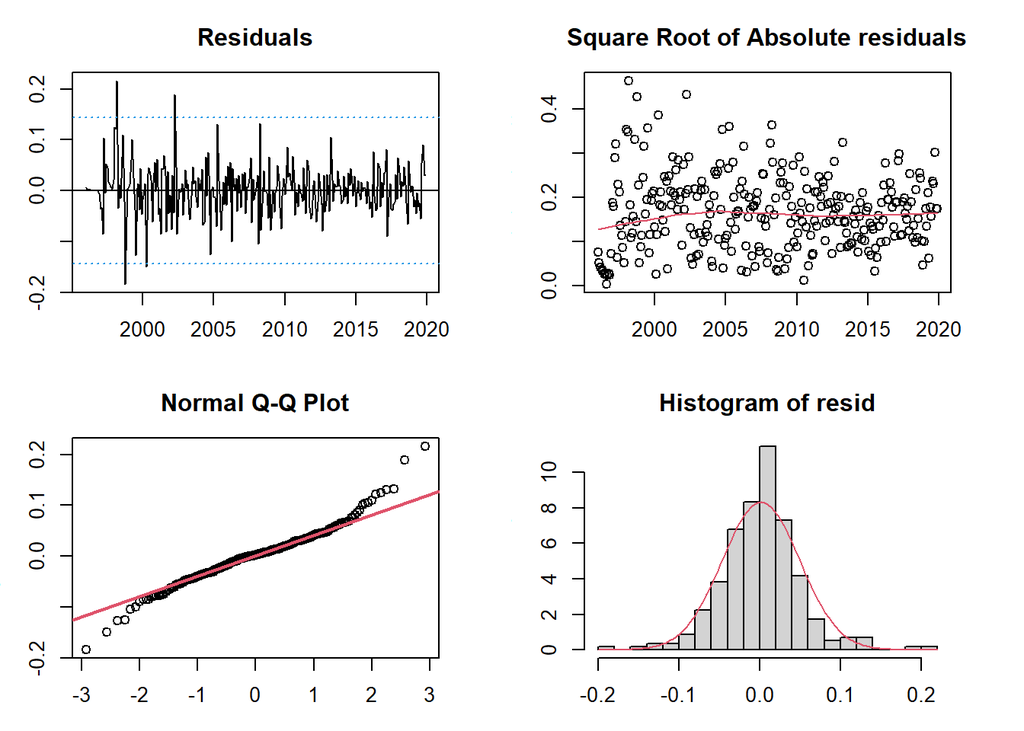

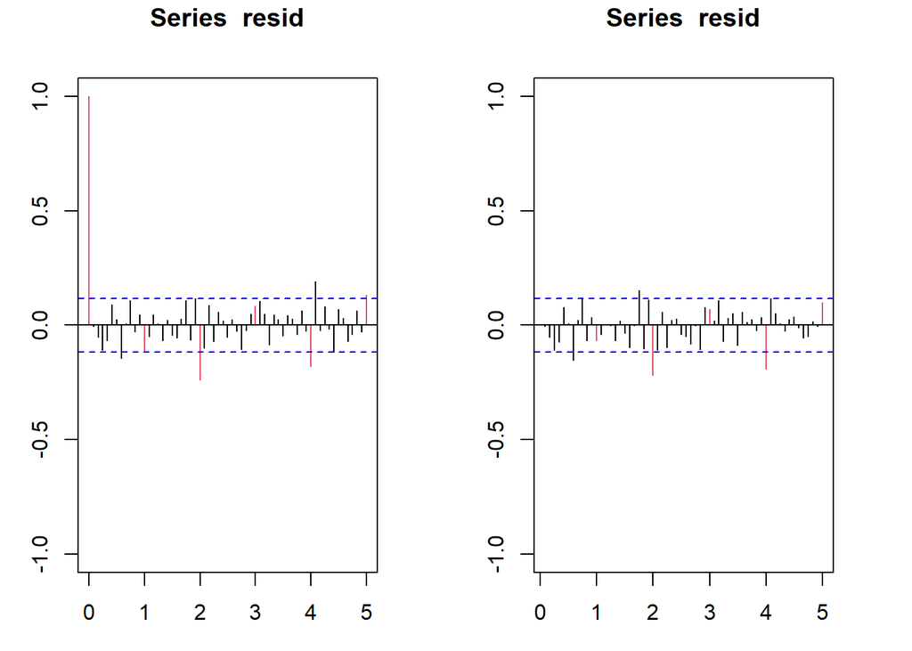

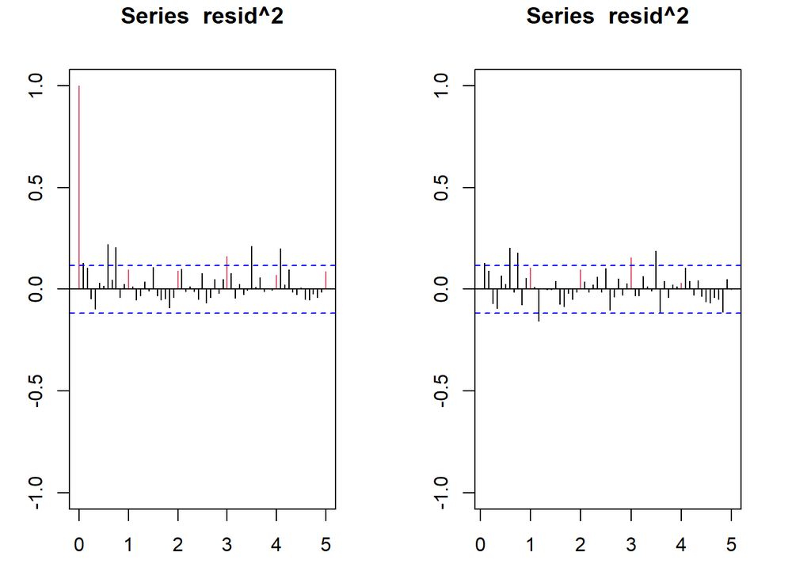

```
##
## --------------------------------------------------------------------
##
## Call:
## arima(x = lnserie, order = c(2, 1, 0), seasonal = list(order = c(1, 1, 0), period = 12))
##
## Coefficients:
##           ar1      ar2     sar1
##       -0.7024  -0.3327  -0.4268
## s.e.   0.0568   0.0568   0.0573
##
## sigma^2 estimated as 0.002396:  log likelihood = 437.95,  aic = -867.91
##
## Modul of AR Characteristic polynomial Roots:  1.073533 1.073533 1.073533 1.073533 1.073533 1.073533 1.073533 1.073533 1.073533 1.073533 1.073533 1.073533 1.73369 1.73369
##
## Modul of MA Characteristic polynomial Roots:
```

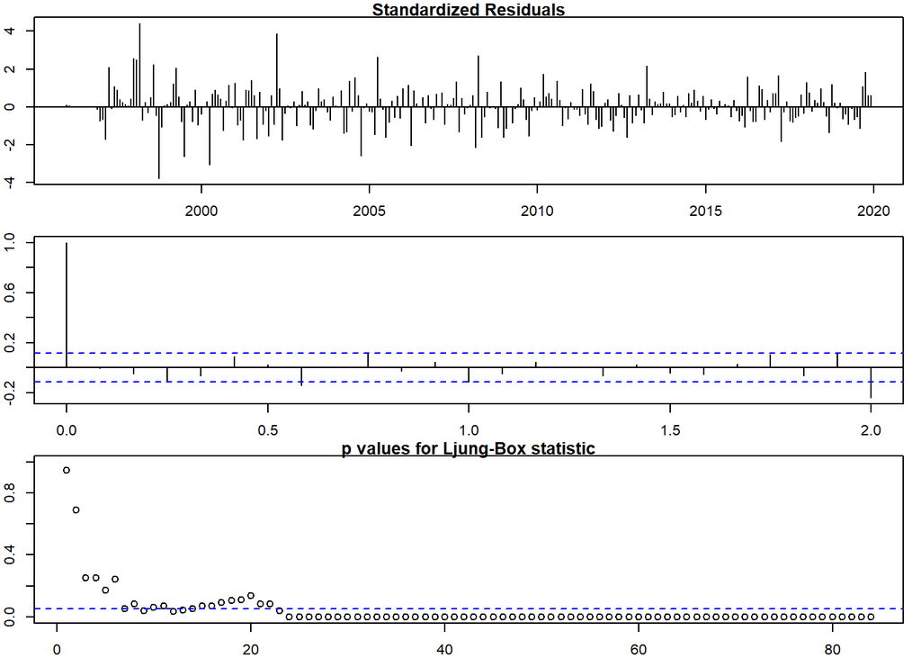

```
##
## Psi-weights (MA(inf))
##
## --------------------
##        psi 1        psi 2        psi 3        psi 4        psi 5        psi 6
## -0.702363092  0.160610548  0.120871644 -0.138331451  0.056944503  0.006027622
##        psi 7        psi 8        psi 9       psi 10       psi 11       psi 12
## -0.023179207  0.014274809 -0.002314299 -0.003123799  0.002964016 -0.427833168
##       psi 13       psi 14       psi 15       psi 16       psi 17       psi 18
##  0.299508089 -0.068021892 -0.051871282  0.059063587 -0.024226333 -0.002634972
##       psi 19       psi 20
##  0.009910890 -0.006084379
##
## Pi-weights (AR(inf))
##
## --------------------
##       pi 1       pi 2       pi 3       pi 4       pi 5       pi 6       pi 7
## -0.7023631 -0.3327034  0.0000000  0.0000000  0.0000000  0.0000000  0.0000000
##       pi 8       pi 9      pi 10      pi 11      pi 12      pi 13      pi 14
##  0.0000000  0.0000000  0.0000000  0.0000000 -0.4267907 -0.2997620 -0.1419947
##      pi 15      pi 16      pi 17      pi 18      pi 19      pi 20
##  0.0000000  0.0000000  0.0000000  0.0000000  0.0000000  0.0000000
##
## Normality Tests
##
## --------------------
##
##  Shapiro-Wilk normality test
##
## data:  resid(model)
## W = 0.96474, p-value = 1.745e-06
##
##
##  Anderson-Darling normality test
##
## data:  resid(model)
## A = 2.2089, p-value = 1.29e-05
```

```
##
##  Jarque Bera Test
##
## data:  resid(model)
## X-squared = 91.943, df = 2, p-value < 2.2e-16
##
##
## Homoscedasticity Test
##
## --------------------
```

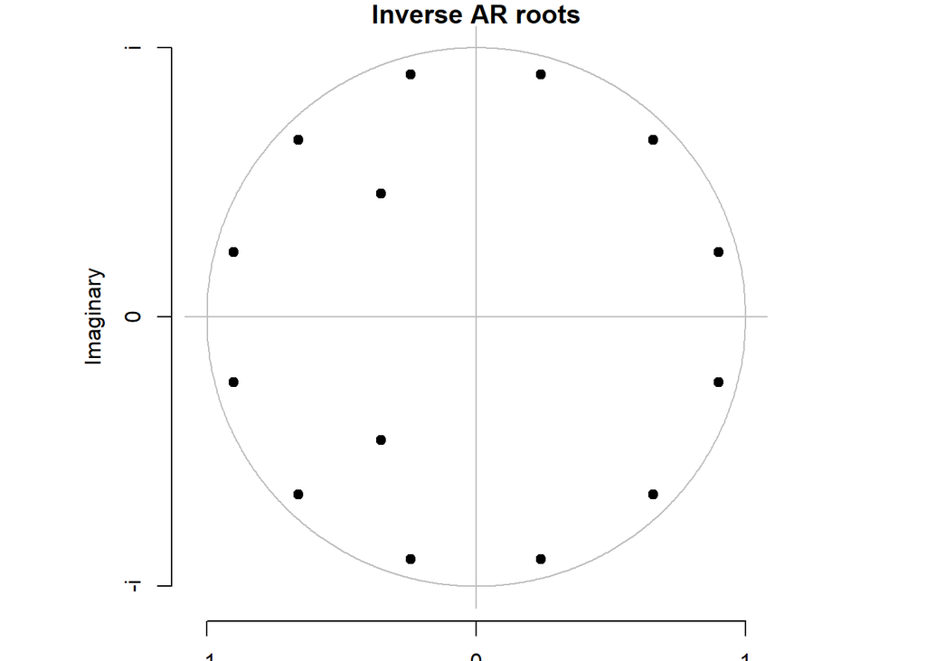

```
##
##  studentized Breusch-Pagan test
##
## data:  resid(model) ~ I(obs - resid(model))
## BP = 1.9041, df = 1, p-value = 0.1676
##
##
## Independence Tests
##
## --------------------
##
##  Durbin-Watson test
##
## data:  resid(model) ~ I(1:length(resid(model)))
## DW = 2.0085, p-value = 0.5052
## alternative hypothesis: true autocorrelation is greater than 0
##
##
## Ljung-Box test
##      lag.df    statistic      p.value
## [1,]      1  0.004346588 9.474346e-01
## [2,]      2  0.745958031 6.886797e-01
## [3,]      3  4.095635282 2.513207e-01
## [4,]      4  5.388265161 2.497270e-01
## [5,]     12 22.337633324 3.390544e-02
## [6,]     24 54.213256590 3.991971e-04
## [7,]     36 70.731065702 4.810279e-04
## [8,]     48 93.529064384 9.222237e-05
```

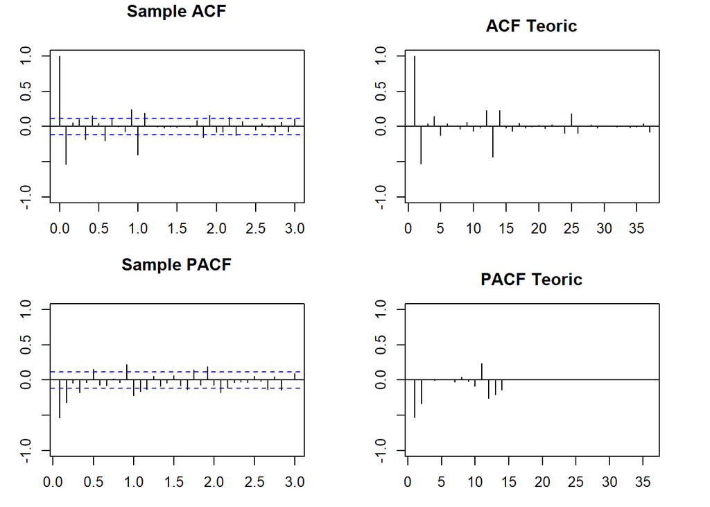

```r
dades=d1d12lnserie #stationary transformed serie
validation(mod1,dades)
```

### Check if the expressions are invertible / causal

Regarding Causality, since we are dealing with an AR model and all the roots of the model lie outside the unit circle (inverse ones lie inside), we can say that the series is causal and stationary, and therefore invertible. This is reflected in the plot of its inverse AR roots.

### Stability check

```r
ultim=c(2018,12)
pdq=c(2,1,0)
PDQ=c(1,1,0)

serie1=window(serie,end=ultim+c(1,0))
lnserie1=log(serie1)
serie2=window(serie,end=ultim)
lnserie2=log(serie2)

(mod11=arima(lnserie1,order=pdq,seasonal=list(order=PDQ,period=12)))
```

```
##
## Call:
## arima(x = lnserie1, order = pdq, seasonal = list(order = PDQ, period = 12))
##
## Coefficients:
##           ar1      ar2     sar1
##       -0.7024  -0.3327  -0.4268
## s.e.   0.0568   0.0568   0.0573
##
## sigma^2 estimated as 0.002396:  log likelihood = 437.95,  aic = -867.91
```

```r
(mod12=arima(lnserie2,order=pdq,seasonal=list(order=PDQ,period=12)))
```

```
##
## Call:
## arima(x = lnserie2, order = pdq, seasonal = list(order = PDQ, period = 12))
##
## Coefficients:
##           ar1      ar2     sar1
##       -0.7139  -0.3424  -0.4265
## s.e.   0.0578   0.0578   0.0583
##
## sigma^2 estimated as 0.002425:  log likelihood = 417.2,  aic = -826.4
```

The model stability is fulfilled. We observe similar results in terms of significance, sign and magnitude. In practice, this means that the correlation structure has not changed in the last year, and that the use of the complete series for making predictions is reliable.

### Capability of prediction

We use the subset series lnserie2 to predict 2019 data

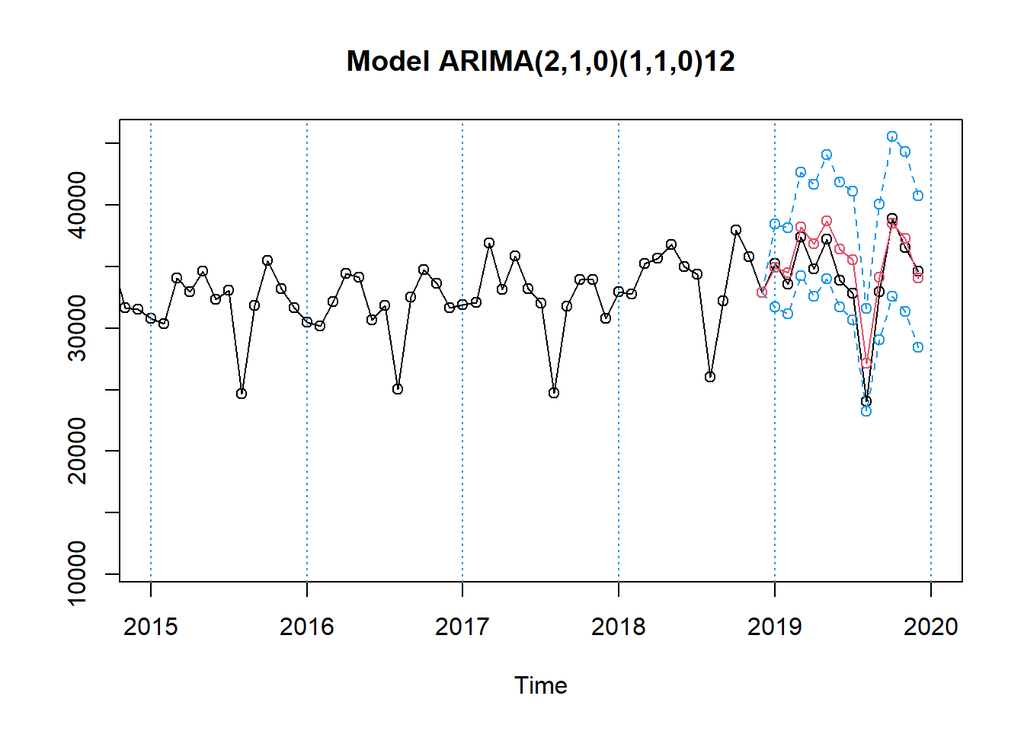

```r
pred=predict(mod12,n.ahead=12)
pr<-ts(c(tail(lnserie2,1),pred$pred),start=ultim,freq=12)

se<-ts(c(0,pred$se),start=ultim,freq=12)

#Intervals
tl<-ts(exp(pr-1.96*se),start=ultim,freq=12)
tu<-ts(exp(pr+1.96*se),start=ultim,freq=12)
pr<-ts(exp(pr),start=ultim,freq=12)

ts.plot(serie,tl,tu,pr,lty=c(1,2,2,1),col=c(1,4,4,2),xlim=ultim[1]+c(-3,+2),type="o",main="Model ARIMA(2,1,0)(1,1,0)12")
abline(v=(ultim[1]-3):(ultim[1]+2),lty=3,col=4)
```

```r
#Tabulate values of: point and interval predictions, observations and prediction-errors.
(previs=window(cbind(tl,pr,tu,serie,error=round(serie-pr,3)),start=ultim))
```

```
##                tl       pr       tu serie     error
## Dec 2018 32868.00 32868.00 32868.00 32868     0.000
## Jan 2019 31689.41 34900.56 38437.11 35235   334.437
## Feb 2019 31179.02 34471.69 38112.09 33538  -933.690
## Mar 2019 34266.88 38232.79 42657.71 37374  -858.795
## Apr 2019 32595.70 36859.13 41680.20 34779 -2080.130
## May 2019 33994.20 38705.73 44070.28 37242 -1463.734
## Jun 2019 31730.60 36435.68 41838.44 33894 -2541.681
## Jul 2019 30683.74 35522.67 41124.71 32808 -2714.668
## Aug 2019 23258.28 27114.97 31611.19 24074 -3040.973
## Sep 2019 29045.13 34103.83 40043.60 32930 -1173.831
## Oct 2019 32585.94 38520.65 45536.22 38912   391.347
## Nov 2019 31318.87 37260.53 44329.41 36547  -713.530
## Dec 2019 28432.20 34038.63 40750.57 34612   573.368
```

```r
#Also, compute and report predictive ability measures: RMSPE and MAPE

obs=window(serie,start=ultim)
mod12.RMSE=sqrt(sum((obs-pr)^2)/12)
mod12.MAE=sum(abs(obs-pr))/12
mod12.RMSPE=sqrt(sum(((obs-pr)/obs)^2)/12)
mod12.MAPE=sum(abs(obs-pr)/obs)/12

data.frame("RMSE"=mod12.RMSE,"MAE"=mod12.MAE,"RMSPE"=mod12.RMSPE,"MAPE"=mod12.MAPE)
```

```
##       RMSE      MAE      RMSPE       MAPE
## 1 1674.231 1401.682 0.05550423 0.04377222
```

```r
mCI1=mean(tu-tl)

cat("\nMean Length CI: ",mCI1)
```

```
##
## Mean Length CI:  9185.506
```

## Model 2

### Analysis of Residuals

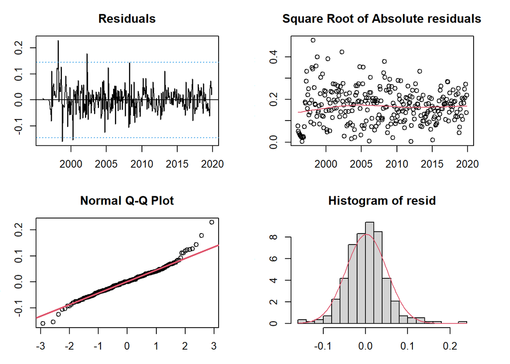

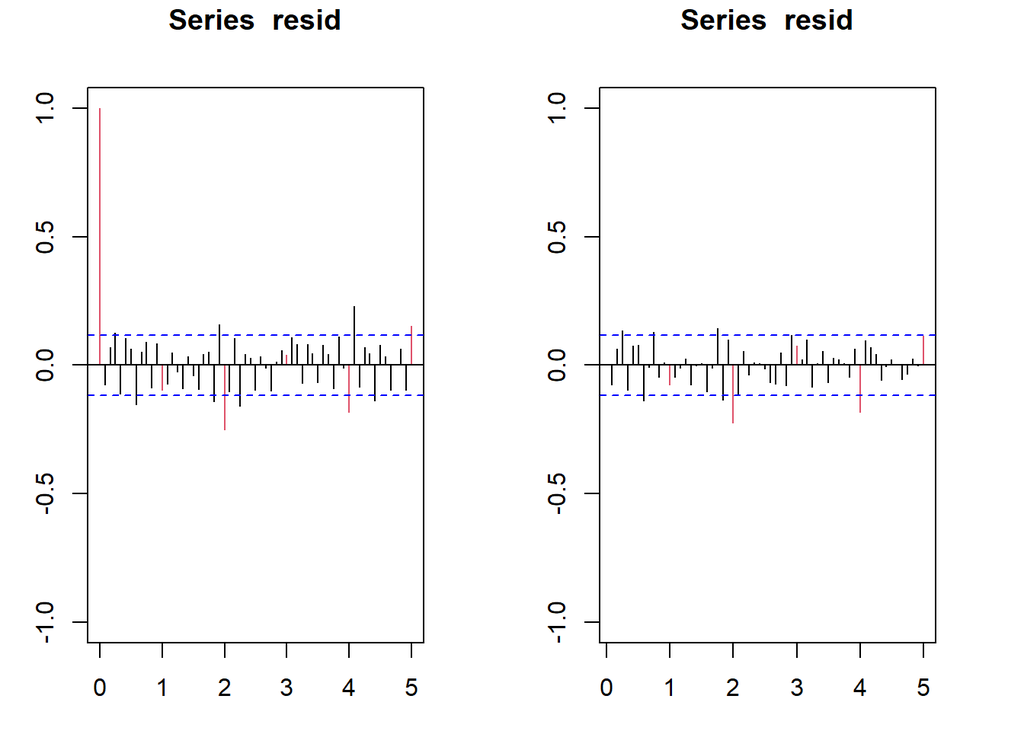

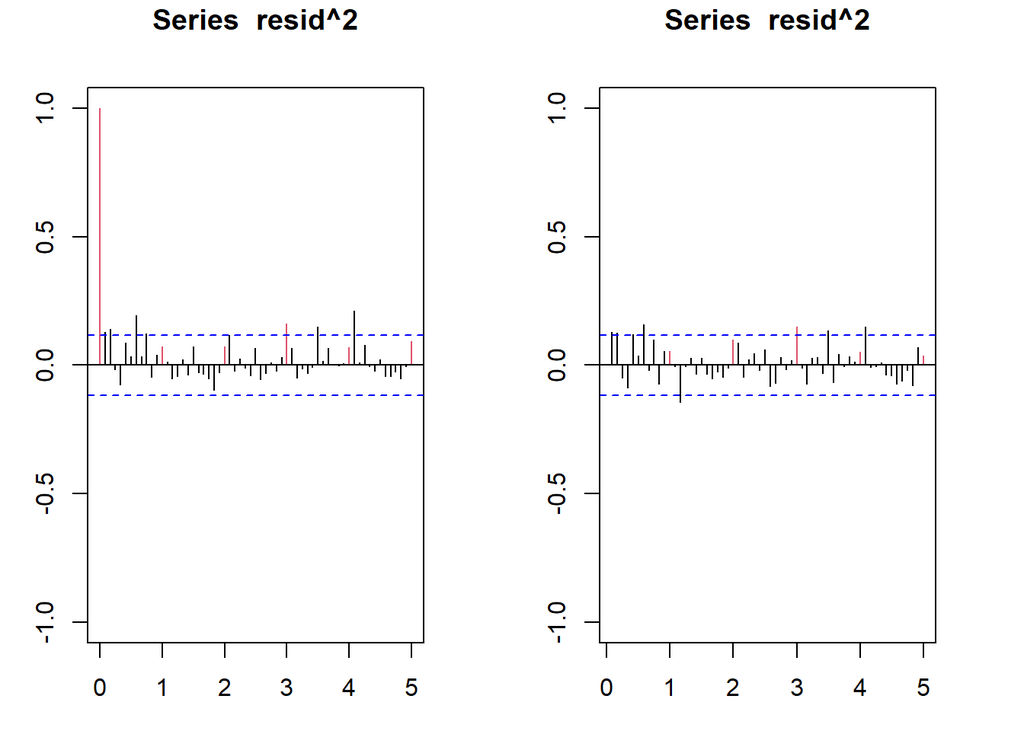

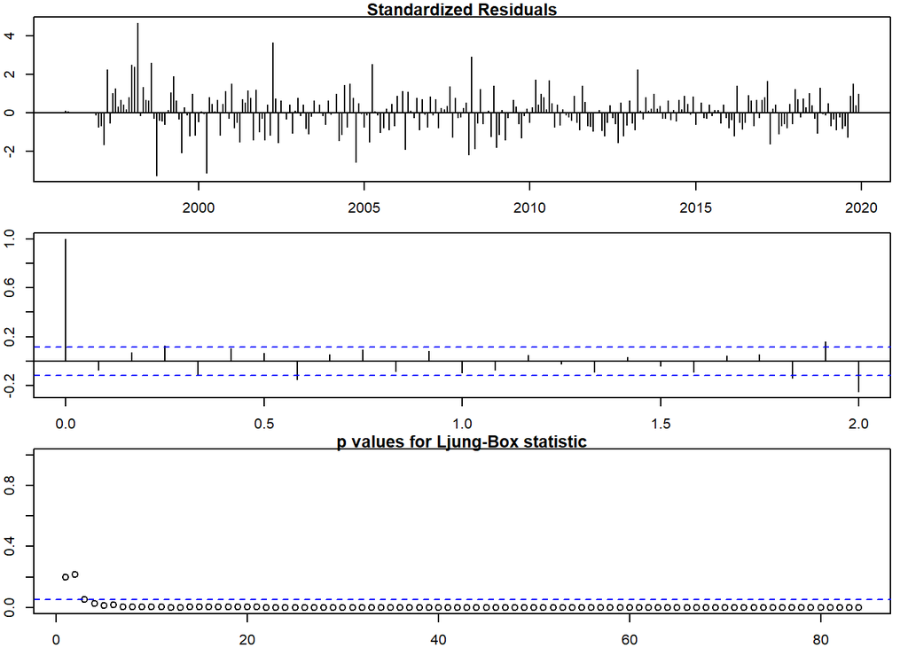

```
##
## --------------------------------------------------------------------
##
## Call:
## arima(x = lnserie, order = c(0, 1, 1), seasonal = list(order = c(1, 1, 0), period = 12))
##
## Coefficients:
##           ma1     sar1
##       -0.6626  -0.4293
## s.e.   0.0435   0.0581
##
## sigma^2 estimated as 0.002432:  log likelihood = 435.91,  aic = -865.81
##
## Modul of AR Characteristic polynomial Roots:  1.073011 1.073011 1.073011 1.073011 1.073011 1.073011 1.073011 1.073011 1.073011 1.073011 1.073011 1.073011
##
## Modul of MA Characteristic polynomial Roots:  1.509273
```

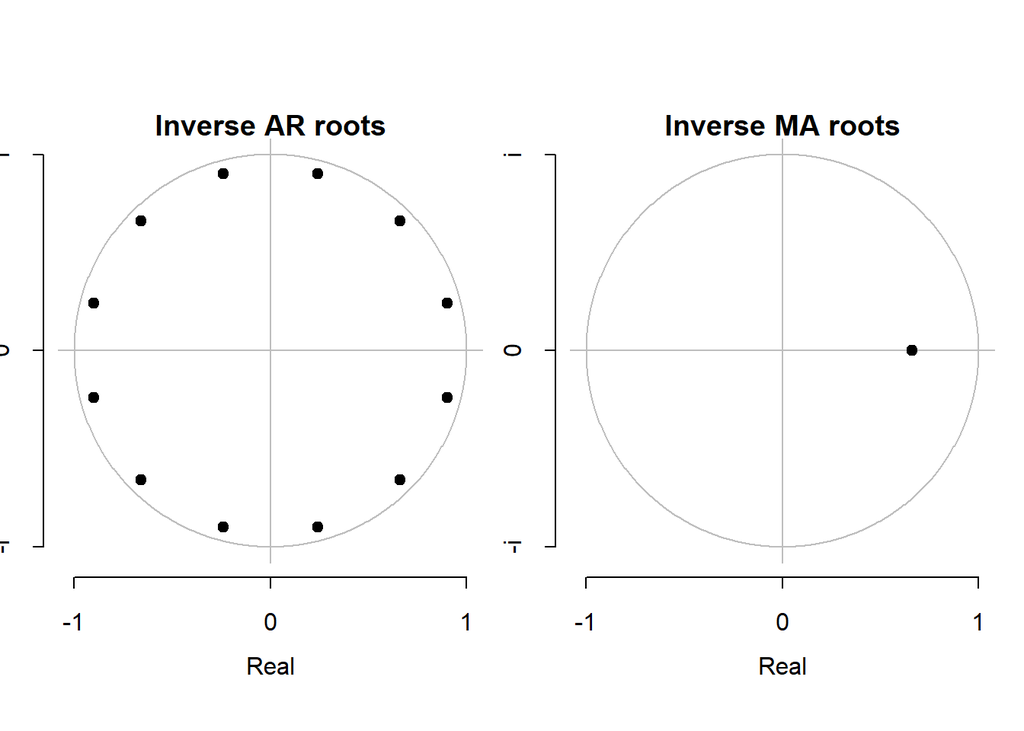

```
##
## Psi-weights (MA(inf))
##
## --------------------
##      psi 1      psi 2      psi 3      psi 4      psi 5      psi 6      psi 7
## -0.6625709  0.0000000  0.0000000  0.0000000  0.0000000  0.0000000  0.0000000
##      psi 8      psi 9     psi 10     psi 11     psi 12     psi 13     psi 14
##  0.0000000  0.0000000  0.0000000  0.0000000 -0.4292896  0.2844348  0.0000000
##     psi 15     psi 16     psi 17     psi 18     psi 19     psi 20
##  0.0000000  0.0000000  0.0000000  0.0000000  0.0000000  0.0000000
##
## Pi-weights (AR(inf))
##
## --------------------
##        pi 1        pi 2        pi 3        pi 4        pi 5        pi 6
## -0.66257086 -0.43900015 -0.29086871 -0.19272113 -0.12769141 -0.08460461
##        pi 7        pi 8        pi 9       pi 10       pi 11       pi 12
## -0.05605655 -0.03714143 -0.02460883 -0.01630510 -0.01080328 -0.43644749
##       pi 13       pi 14       pi 15       pi 16       pi 17       pi 18
## -0.28917739 -0.19160051 -0.12694892 -0.08411265 -0.05573059 -0.03692547
##       pi 19       pi 20
## -0.02446574 -0.01621029
##
## Normality Tests
##
## --------------------
##
##  Shapiro-Wilk normality test
##
## data:  resid(model)
## W = 0.97122, p-value = 1.568e-05
##
##
##  Anderson-Darling normality test
##
## data:  resid(model)
## A = 1.3508, p-value = 0.001655
##
##
##  Jarque Bera Test
```

[output cut: 21 more lines]

```
## data:  resid(model) ~ I(1:length(resid(model)))
## DW = 2.1533, p-value = 0.8935
## alternative hypothesis: true autocorrelation is greater than 0
##
##
## Ljung-Box test
##      lag.df  statistic      p.value
## [1,]      1   1.652204 1.986592e-01
## [2,]      2   3.066352 2.158491e-01
## [3,]      3   7.649680 5.383473e-02
## [4,]      4  11.183142 2.458105e-02
## [5,]     12  32.865527 1.015902e-03
## [6,]     24  76.304337 2.334133e-07
## [7,]     36 100.384645 5.432327e-08
## [8,]     48 134.046389 4.577349e-10
```

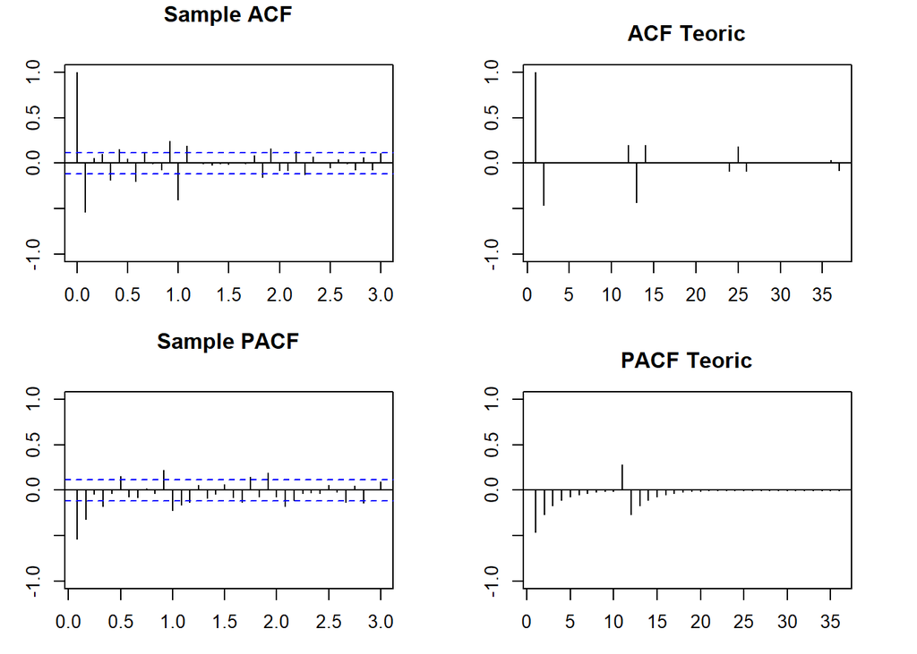

```r
validation(mod2,dades)
```

When looking at the normality plots or the residuals, they present bad alignments in the tails. The square roots of their absolute values, do not present a constant variance at first, but the Homoscedasticity test does not allow to confirm this with enough confidence. The Saphiro-Wilk Test also allows the rejection of the null hypothesis of normality with 0.05 confidence level.

### Check if the expressions are invertible / causal

By taking a look at the plot of the inverse AR and MA roots, it can be observed that none of the inverse roots lie outside the unit circle for both parts. This is an indicator that the series are stationary, causal and therefore invertible.

### Stability check

```r
ultim=c(2018,12)
pdq=c(0,1,1)
PDQ=c(1,1,0)

serie1=window(serie,end=ultim+c(1,0))
lnserie1=log(serie1)
serie2=window(serie,end=ultim)
lnserie2=log(serie2)

(mod21=arima(lnserie1,order=pdq,seasonal=list(order=PDQ,period=12)))
```

```
##
## Call:
## arima(x = lnserie1, order = pdq, seasonal = list(order = PDQ, period = 12))
##
## Coefficients:
##           ma1     sar1
##       -0.6626  -0.4293
## s.e.   0.0435   0.0581
##
## sigma^2 estimated as 0.002432:  log likelihood = 435.91,  aic = -865.81
```

```r
(mod22=arima(lnserie2,order=pdq,seasonal=list(order=PDQ,period=12)))
```

```
##
## Call:
## arima(x = lnserie2, order = pdq, seasonal = list(order = PDQ, period = 12))
##
## Coefficients:
##           ma1     sar1
##       -0.6675  -0.4284
## s.e.   0.0431   0.0594
##
## sigma^2 estimated as 0.002465:  log likelihood = 415.04,  aic = -824.08
```

The model stability is fulfilled. We observe similar results in terms of significance, sign and magnitude. In practice, this means that the correlation structure has not changed in the last year, and that the use of the complete series for making predictions is reliable.

### Capability of prediction

We use the subset series lnserie2 to predict 2019 data

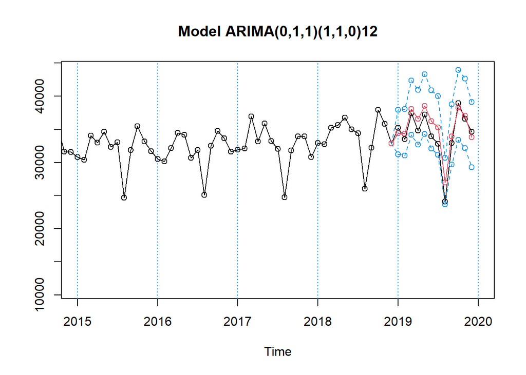

```r
pred=predict(mod22,n.ahead=12)
pr<-ts(c(tail(lnserie2,1),pred$pred),start=ultim,freq=12)

se<-ts(c(0,pred$se),start=ultim,freq=12)

#Intervals
tl<-ts(exp(pr-1.96*se),start=ultim,freq=12)
tu<-ts(exp(pr+1.96*se),start=ultim,freq=12)
pr<-ts(exp(pr),start=ultim,freq=12)

ts.plot(serie,tl,tu,pr,lty=c(1,2,2,1),col=c(1,4,4,2),xlim=ultim[1]+c(-3,+2),type="o",main="Model ARIMA(0,1,1)(1,1,0)12")
abline(v=(ultim[1]-3):(ultim[1]+2),lty=3,col=4)
```

```r
#Tabulate values of: point and interval predictions, observations and prediction-errors.
(previs=window(cbind(tl,pr,tu,serie,error=round(serie-pr,3)),start=ultim))
```

```
##                tl       pr       tu serie     error
## Dec 2018 32868.00 32868.00 32868.00 32868     0.000
## Jan 2019 31206.74 34396.16 37911.55 35235   838.839
## Feb 2019 31013.76 34363.03 38073.98 33538  -825.025
## Mar 2019 34159.83 38037.97 42356.39 37374  -663.967
## Apr 2019 32689.59 36574.61 40921.36 34779 -1795.614
## May 2019 34257.17 38504.03 43277.38 37242 -1262.032
## Jun 2019 32075.63 36210.94 40879.37 33894 -2316.935
## Jul 2019 31132.69 35295.87 40015.78 32808 -2487.874
## Aug 2019 23678.01 26954.74 30684.92 24074 -2880.740
## Sep 2019 29657.39 33896.17 38740.78 32930  -966.168
## Oct 2019 33363.92 38280.07 43920.60 38912   631.934
## Nov 2019 32157.14 37034.36 42651.31 36547  -487.363
## Dec 2019 29266.86 33829.32 39103.02 34612   782.684
```

```r
#Also, compute and report predictive ability measures: RMSPE and MAPE

obs=window(serie,start=ultim)
mod22.RMSE=sqrt(sum((obs-pr)^2)/12)
mod22.MAE=sum(abs(obs-pr))/12
mod22.RMSPE=sqrt(sum(((obs-pr)/obs)^2)/12)
mod22.MAPE=sum(abs(obs-pr)/obs)/12

data.frame("RMSE"=mod22.RMSE,"MAE"=mod22.MAE,"RMSPE"=mod22.RMSPE,"MAPE"=mod22.MAPE)
```

```
##       RMSE      MAE      RMSPE       MAPE
## 1 1546.001 1328.265 0.05152461 0.04142239
```

```r
mCI2=mean(tu-tl)

cat("\nMean Length CI: ",mCI2)
```

```
##
## Mean Length CI:  7990.594
```

## Best model selection

```r
results=data.frame(
  par=c(length(coef(mod12)),length(coef(mod22))),
  Sigma2Z=c(mod12$sigma2,mod22$sigma2),
  AIC=c(AIC(mod12),AIC(mod22)),
  BIC=c(BIC(mod12),BIC(mod22)),
   RMSE=c(mod12.RMSE,mod22.RMSE),
  MAE=c(mod12.MAE,mod22.MAE),
  RMSPE=c(mod12.RMSPE,mod22.RMSPE),
  MAPE=c(mod12.MAPE,mod22.MAPE),
  meanLength=c(mCI1,mCI2)
  )

row.names(results)=c("ARIMA(2,1,0)(1,1,0)12","ARIMA(0,1,1)(1,1,0)12")
results
```

```
##                       par     Sigma2Z       AIC       BIC     RMSE      MAE
## ARIMA(2,1,0)(1,1,0)12   3 0.002425080 -826.4047 -812.1160 1674.231 1401.682
## ARIMA(0,1,1)(1,1,0)12   2 0.002464957 -824.0767 -813.3602 1546.001 1328.265
##                            RMSPE       MAPE meanLength
## ARIMA(2,1,0)(1,1,0)12 0.05550423 0.04377222   9185.506
## ARIMA(0,1,1)(1,1,0)12 0.05152461 0.04142239   7990.594
```

From the results, it can be seen that model 2, despite having a higher AIC (but for a little), has a better prediction capability, because focusing on the error metric, it has less predictive error.

# 4. Prediction

## Perform long term predictions

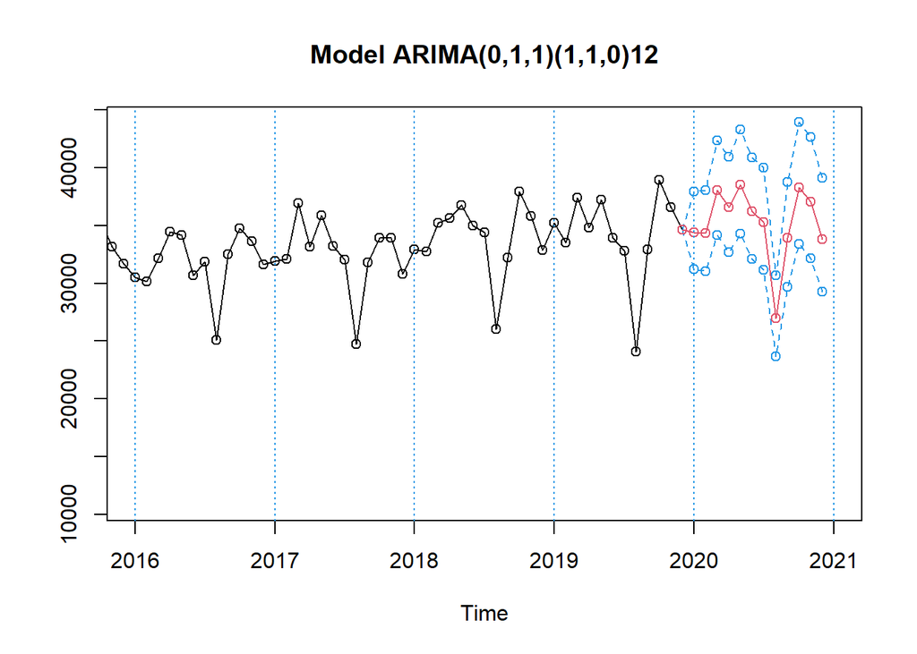

```r
pred=predict(mod22,n.ahead=12)
pr<-ts(c(tail(lnserie,1),pred$pred),start=ultim+c(1,0),freq=12)
se<-ts(c(0,pred$se),start=ultim+c(1,0),freq=12)

#Intervals
tl1<-ts(exp(pr-1.96*se),start=ultim+c(1,0),freq=12)
tu1<-ts(exp(pr+1.96*se),start=ultim+c(1,0),freq=12)
pr1<-ts(exp(pr),start=ultim+c(1,0),freq=12)

ts.plot(serie,tl1,tu1,pr1,lty=c(1,2,2,1),col=c(1,4,4,2),xlim=c(ultim[1]-2,ultim[1]+3),type="o",main="Model ARIMA(0,1,1)(1,1,0)12")
abline(v=(ultim[1]-2):(ultim[1]+3),lty=3,col=4)
```

```r
(previs1=window(cbind(tl1,pr1,tu1),start=ultim+c(1,0)))
```

```
##               tl1      pr1      tu1
## Dec 2019 34612.00 34612.00 34612.00
## Jan 2020 31206.74 34396.16 37911.55
## Feb 2020 31013.76 34363.03 38073.98
## Mar 2020 34159.83 38037.97 42356.39
## Apr 2020 32689.59 36574.61 40921.36
## May 2020 34257.17 38504.03 43277.38
## Jun 2020 32075.63 36210.94 40879.37
## Jul 2020 31132.69 35295.87 40015.78
## Aug 2020 23678.01 26954.74 30684.92
## Sep 2020 29657.39 33896.17 38740.78
## Oct 2020 33363.92 38280.07 43920.60
## Nov 2020 32157.14 37034.36 42651.31
## Dec 2020 29266.86 33829.32 39103.02
```

# 5. Calendar effects & Outlier Treatment

## Calendar effects

```r
source("CalendarEffects.r")
data=c(start(lnserie)[1],start(lnserie)[2], length(lnserie))
(wTradDays=Wtrad(data))
```

```
##       Jan  Feb  Mar  Apr  May  Jun  Jul  Aug  Sep  Oct  Nov  Dec
## 1996  3.0  1.0 -4.0  2.0  3.0 -5.0  3.0 -0.5 -1.5  3.0 -1.5 -0.5
## 1997  3.0  0.0 -4.0  2.0 -0.5 -1.5  3.0 -4.0  2.0  3.0 -5.0  3.0
## 1998 -0.5  0.0 -0.5  2.0 -4.0  2.0  3.0 -4.0  2.0 -0.5 -1.5  3.0
## 1999 -4.0  0.0  3.0  2.0 -4.0  2.0 -0.5 -0.5  2.0 -4.0  2.0  3.0
## 2000 -4.0  1.0  3.0 -5.0  3.0  2.0 -4.0  3.0 -1.5 -0.5  2.0 -4.0
## 2001  3.0  0.0 -0.5 -1.5  3.0 -1.5 -0.5  3.0 -5.0  3.0  2.0 -4.0
## 2002  3.0  0.0 -4.0  2.0  3.0 -5.0  3.0 -0.5 -1.5  3.0 -1.5 -0.5
## 2003  3.0  0.0 -4.0  2.0 -0.5 -1.5  3.0 -4.0  2.0  3.0 -5.0  3.0
## 2004 -0.5 -2.5  3.0  2.0 -4.0  2.0 -0.5 -0.5  2.0 -4.0  2.0  3.0
## 2005 -4.0  0.0  3.0 -1.5 -0.5  2.0 -4.0  3.0  2.0 -4.0  2.0 -0.5
## 2006 -0.5  0.0  3.0 -5.0  3.0  2.0 -4.0  3.0 -1.5 -0.5  2.0 -4.0
## 2007  3.0  0.0 -0.5 -1.5  3.0 -1.5 -0.5  3.0 -5.0  3.0  2.0 -4.0
## 2008  3.0  1.0 -4.0  2.0 -0.5 -1.5  3.0 -4.0  2.0  3.0 -5.0  3.0
## 2009 -0.5  0.0 -0.5  2.0 -4.0  2.0  3.0 -4.0  2.0 -0.5 -1.5  3.0
## 2010 -4.0  0.0  3.0  2.0 -4.0  2.0 -0.5 -0.5  2.0 -4.0  2.0  3.0
## 2011 -4.0  0.0  3.0 -1.5 -0.5  2.0 -4.0  3.0  2.0 -4.0  2.0 -0.5
## 2012 -0.5  1.0 -0.5 -1.5  3.0 -1.5 -0.5  3.0 -5.0  3.0  2.0 -4.0
## 2013  3.0  0.0 -4.0  2.0  3.0 -5.0  3.0 -0.5 -1.5  3.0 -1.5 -0.5
## 2014  3.0  0.0 -4.0  2.0 -0.5 -1.5  3.0 -4.0  2.0  3.0 -5.0  3.0
## 2015 -0.5  0.0 -0.5  2.0 -4.0  2.0  3.0 -4.0  2.0 -0.5 -1.5  3.0
## 2016 -4.0  1.0  3.0 -1.5 -0.5  2.0 -4.0  3.0  2.0 -4.0  2.0 -0.5
## 2017 -0.5  0.0  3.0 -5.0  3.0  2.0 -4.0  3.0 -1.5 -0.5  2.0 -4.0
## 2018  3.0  0.0 -0.5 -1.5  3.0 -1.5 -0.5  3.0 -5.0  3.0  2.0 -4.0
## 2019  3.0  0.0 -4.0  2.0  3.0 -5.0  3.0 -0.5 -1.5  3.0 -1.5 -0.5
```

```r
(wEast=Weaster(data))
```

```
##             Jan        Feb        Mar        Apr        May        Jun
## 1996  0.0000000  0.0000000 -0.5000000  0.5000000  0.0000000  0.0000000
## 1997  0.0000000  0.0000000  0.5000000 -0.5000000  0.0000000  0.0000000
## 1998  0.0000000  0.0000000 -0.5000000  0.5000000  0.0000000  0.0000000
## 1999  0.0000000  0.0000000  0.0000000  0.0000000  0.0000000  0.0000000
## 2000  0.0000000  0.0000000 -0.5000000  0.5000000  0.0000000  0.0000000
## 2001  0.0000000  0.0000000 -0.5000000  0.5000000  0.0000000  0.0000000
## 2002  0.0000000  0.0000000  0.5000000 -0.5000000  0.0000000  0.0000000
## 2003  0.0000000  0.0000000 -0.5000000  0.5000000  0.0000000  0.0000000
## 2004  0.0000000  0.0000000 -0.5000000  0.5000000  0.0000000  0.0000000
## 2005  0.0000000  0.0000000  0.5000000 -0.5000000  0.0000000  0.0000000
## 2006  0.0000000  0.0000000 -0.5000000  0.5000000  0.0000000  0.0000000
## 2007  0.0000000  0.0000000 -0.5000000  0.5000000  0.0000000  0.0000000
## 2008  0.0000000  0.0000000  0.5000000 -0.5000000  0.0000000  0.0000000
## 2009  0.0000000  0.0000000 -0.5000000  0.5000000  0.0000000  0.0000000
```

[output cut: 35 more lines]

```r
T1=ts(rep(0,length(lnserie)),start=1996,freq=12)
T1[235:length(lnserie)]=1
```

```r
(modEC=arima(lnserie,order=c(0,1,1), seasonal=list(order=c(1,1,0),period=12),xreg=data.frame(wTradDays,wEast)))
```

```
##
## Call:
## arima(x = lnserie, order = c(0, 1, 1), seasonal = list(order = c(1, 1, 0), period = 12),
##     xreg = data.frame(wTradDays, wEast))
##
## Coefficients:
##           ma1     sar1  wTradDays    wEast
##       -0.3941  -0.3614     0.0052  -0.0779
## s.e.   0.0615   0.0594     0.0005   0.0058
##
## sigma^2 estimated as 0.001197:  log likelihood = 533.94,  aic = -1057.88
```

```r
abs(modEC$coef/sqrt(diag(modEC$var.coef)))
```

```
##       ma1      sar1 wTradDays     wEast
##  6.411996  6.081109 11.498511 13.347912
```

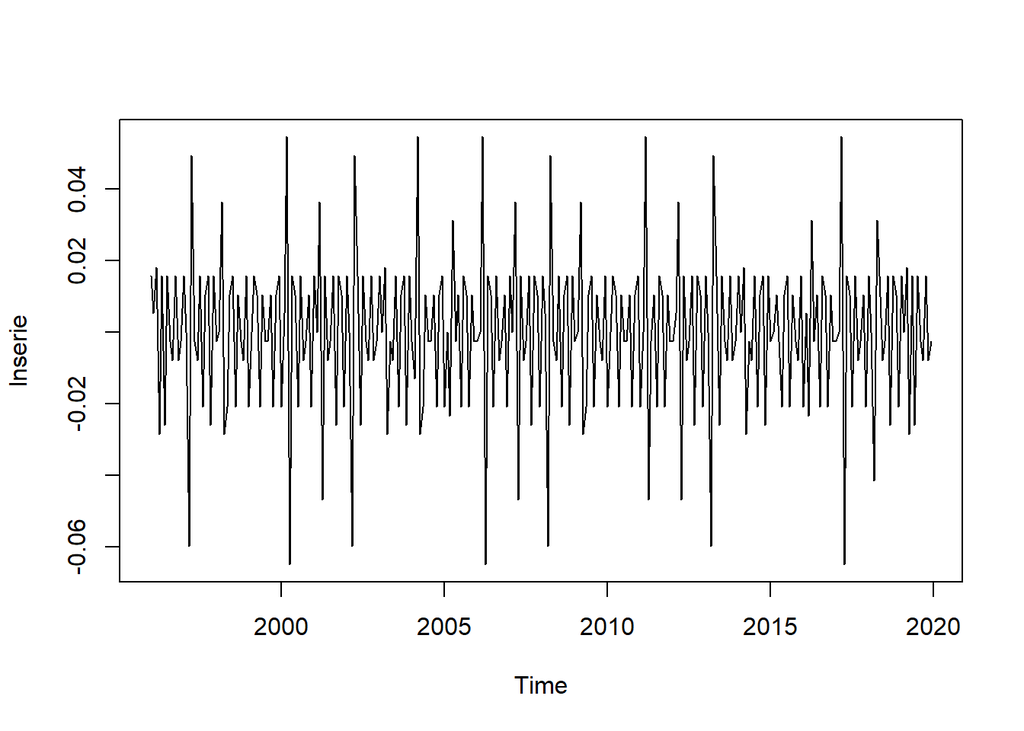

```r
EfecTD=coef(modEC)["wTradDays"]*wTradDays
EfecSS=coef(modEC)["wEast"]*wEast
lnserieEC=lnserie-EfecTD-EfecSS
plot(lnserie-lnserieEC)
```